# Analisi della rete dei blog politici USA

2025-07-19

## 1. Introduzione e motivazione

- Le **reti sociali online** aiutano a comprendere fenomeni di **opinione**, di **diffusione delle informazioni** e di **polarizzazione**
- Questo studio analizza la **blogosfera politica americana del 2004** come caso emblematico
- L’obiettivo è indagare come la **struttura delle connessioni** rifletta (o meno) la **divisione ideologica** all’interno della società digitale presa in analisi

**Domande di ricerca:**

- La struttura delle connessioni riflette la **polarizzazione politica**?
- Chi sono i blog più **influenti** o **centrali** nella rete?
- Esistono blog **“ponte”** tra le fazioni?
- Le **community** individuate coincidono con gli schieramenti politici?
- La rete mostra **proprietà globali** tipiche delle reti sociali reali?

Queste domande guideranno l’analisi presentata nelle prossime slide.

## 2. Descrizione del dataset e prime informazioni

- **Dataset**: blog politici USA, raccolti nel **2004** (Adamic & Glance) –> reale e ben documentato
- **Nodi**: blog, con orientamento politico (*liberal = 0/blu, conservative = 1/rosso*)
- **Archi**: link tra blog, **rete diretta**

Caratteristiche principali

| Metadato | Valore |
| --- | --- |
| Numero nodi | 1490 |
| Numero archi | 19090 |
| Blog liberal (0) | 758 |
| Blog conservative (1) | 732 |
| Componenti connesse | 268 |
| Nodi del Core | 1222 |
| Nodi isolati | 266 |

- Grande **componente principale** (“core” connesso)
- Molti **nodi isolati** e **piccoli gruppi marginali**

## 2.1 Visualizzazione della struttura

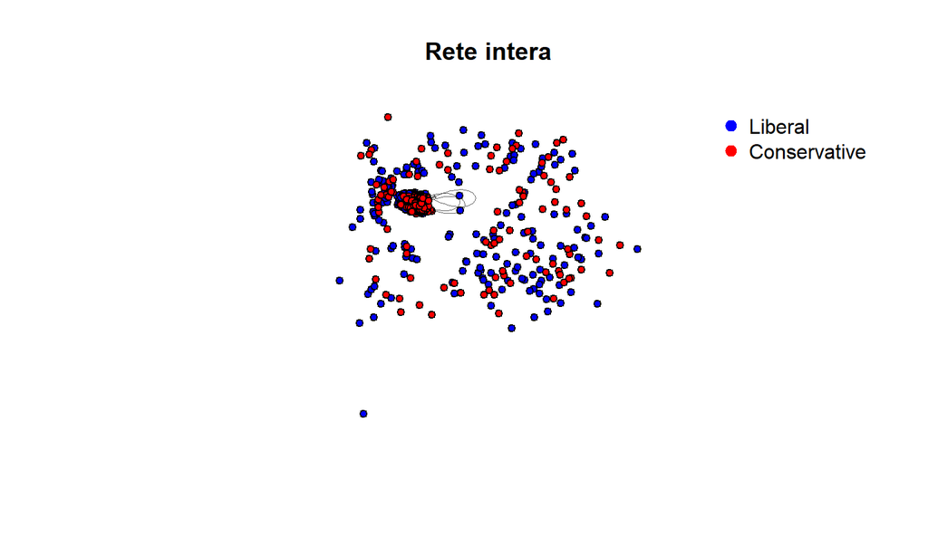

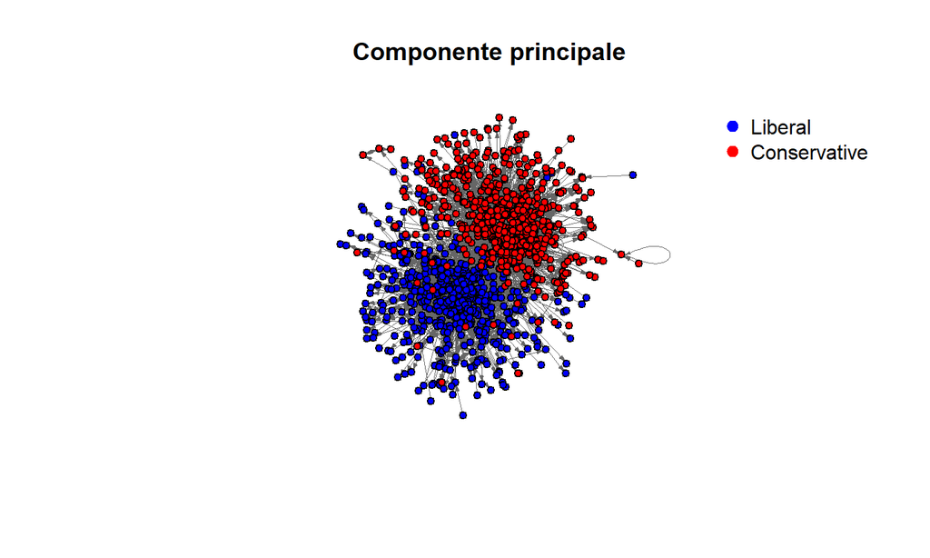

- La **componente principale** (“core”) raccoglie la maggioranza dei blog attivi e delle interazioni
- Le **componenti periferiche** sono costituite da piccoli gruppi o nodi isolati, con ruolo **marginale** nella struttura e dinamica globale
- I **colori** mostrano l’**aggregazione politica**, ma i due gruppi non sono separati in modo assoluto: **presenti dei collegamenti trasversali**

Nei passaggi delle prossime slide vedremo come **queste connessioni** e l’**aggregazione politica** influenzano le proprietà della rete.

## 3. Analisi locale: Centralità

- L’**Obiettivo** è identificare i blog più influenti tramite:
  - **In-degree** (popolarità)
  - **Betweenness** (ponte tra gruppi)
  - **PageRank** (autorevolezza globale)

Visualizziamo i risultati con dei grafici rappresentativi per i **top 10 blog** per le tre misure appena discusse, caratterizzati per orientamento politico.

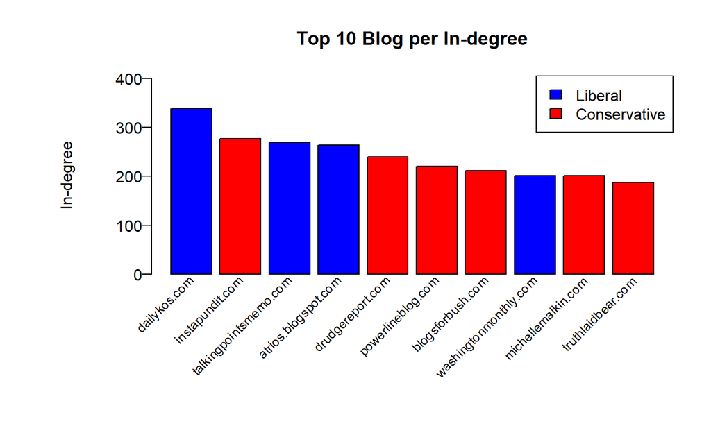

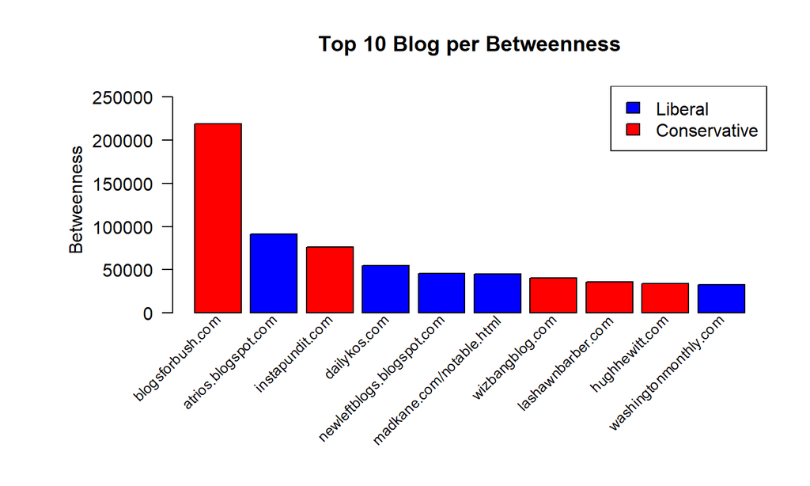

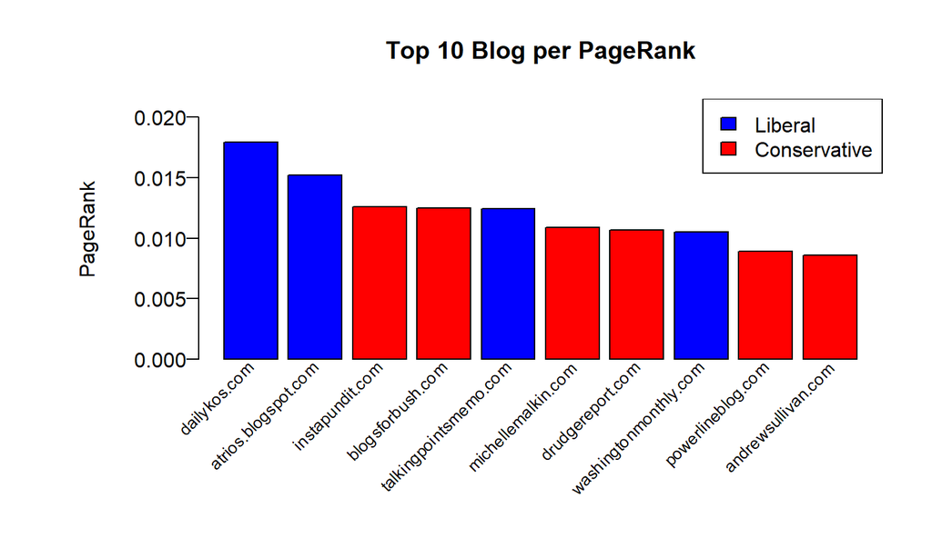

Osserviamo che i **ruoli di centralità** non sono concentrati su un solo schieramento: **entrambe le fazioni** presentano **blog chiave**, e non sempre i più citati sono anche i più influenti nella rete nel suo complesso.

## 4. Community detection: Infomap

**Infomap** rileva le comunità ottimizzando la compressione delle traiettorie casuali sulla rete.

**Sull’intera rete:**

- Risultato frammentato a causa di tanti **nodi isolati** e **micro-cluster**

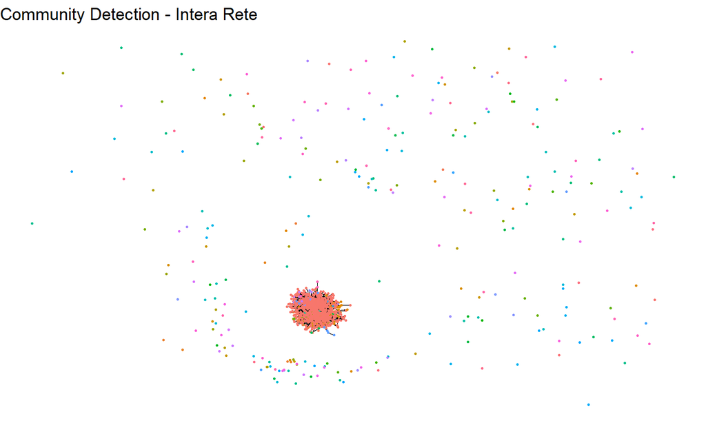

**Sulla componente principale:**

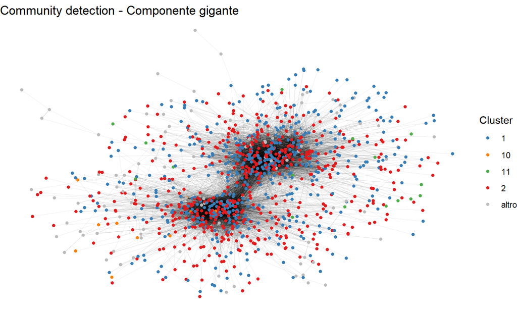

## 4.1 Principali cluster e modularità

Suddivisione politica nei 4 cluster principali del “core”

| Cluster | N_nodi | Liberal | Conservative |
| --- | --- | --- | --- |
| 2 | 553 | 277 | 276 |
| 1 | 529 | 225 | 304 |
| 11 | 16 | 12 | 4 |
| 10 | 10 | 10 | 0 |

```
## Modularità globale della componente gigante: 0.027
```

- La **modularità bassa** conferma che **la polarizzazione è presente, ma non estrema**: i blog di orientamento opposto non sono completamente separati
- Nei principali **cluster** coesistono **entrambe le ideologie politiche**

## 5. Analisi globale e confronto tra rete totale e componente principale

Confronto delle metriche globali: rete completa vs componente principale

| Metrica | Rete.completa | Componente.principale |
| --- | --- | --- |
| Numero nodi | 1490.000 | 1222.000 |
| Numero archi | 19090.000 | 19089.000 |
| Componenti connesse | 268.000 | 1.000 |
| Diametro | 9.000 | 9.000 |
| Lunghezza media del cammino | 3.390 | 3.390 |
| Reciprocità | 0.240 | 0.240 |
| Assortatività (politica) | 0.823 | 0.823 |
| Modularità (Infomap) | 0.024 | 0.027 |

- La **quasi totalità** delle proprietà strutturali della rete è **determinata dalla componente principale**
- Le **metriche** calcolate sull’intera rete e sulla componente principale sono **praticamente identiche**
- La completa maggioranza dei **nodi attivi** e degli **archi** si concentra nel **nucleo connesso** della blogosfera
- I **nodi isolati o periferici** hanno **impatto trascurabile sulle proprietà globali**

## 5.1 Metriche

- **Diametro**: massima distanza tra due blog → indica l’estensione massima della rete
  - **Basso**: tutti i nodi **raggiungibili in pochi passi**
- **Lunghezza media del cammino**: media delle distanze minime → quanto sono “vicini” mediamente i blog
  - **Basso**: rete molto **compatta**
- **Assortatività**: tendenza a collegarsi a blog simili → segregazione politica
  - **Alta**: blog si collegano tra simili, con **tendenza alla polarizzazione**
- **Modularità**: separazione netta tra gruppi → quanto sono divise le fazioni
  - **Bassa**: le divisioni **non sono nette** ma comunicano tra loro
- **Reciprocità**: relazioni bidirezionali → dialogo reciproco vs. monologo
  - Una **parte significativa** dei **link** è **di ritorno**, con conversazioni o riconoscimenti reciproci tra i vari blog

## 5.2 Distribuzione dei gradi per nodo

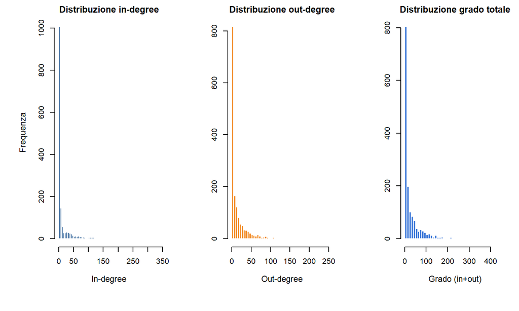

- La maggior parte dei blog ha **pochi collegamenti** in entrata/uscita
- La distribuzione mostra una **coda lunga**: pochissimi blog hanno un grado molto elevato (super-hub), mentre la maggior parte ha pochi collegamenti
- Alcuni blog hanno un **in-degree molto alto**: sono i più citati, spesso veri ‘hub’ della rete
- La distribuzione è **fortemente sbilanciata**: pochissimi blog sono collegati a moltissimi altri, la maggioranza invece resta marginale

Tutto questo cosa significa?

## 5.3 Scale-free e Small world

**La rete è “scale-free”**

- La **distribuzione dei gradi** segue una **power-law**
- Quasi tutti i blog hanno pochi collegamenti, un numero minimo ne hanno moltissimi
- Questo favorisce la **diffusione rapida** delle idee, ma anche la concentrazione del potere informativo

**La rete è anche “small-world”**

- La distanza media tra due blog è molto bassa, tipica dei social network
- La maggior parte dei nodi è raggiungibile in **pochissimi passaggi**
- Permette una **rapida propagazione delle informazioni** e facilita l’interazione tra punti anche lontani

La combinazione di proprietà ‘scale-free’ e ‘small-world’ rende la blogosfera un ambiente ideale per la rapida diffusione delle informazioni, ma la rende anche **vulnerabile al controllo o alla rimozione dei nodi più centrali**. Queste sono due caratteristiche riscontrate in moltissime reti sociali reali, dai blog ai social network moderni come Facebook e X.

## 6. Conclusioni

L’analisi condotta permette di rispondere alle domande di ricerca iniziali, fornendo una visione articolata della blogosfera politica americana nel 2004. In sintesi:

- **Polarizzazione?**
  - Sì, ma non totale: due aree principali + collegamenti tra gruppi
- **Chi sono i blog centrali?**
  - Ruoli chiave in entrambi gli schieramenti (liberal e conservative)
- **Blog “ponte”?**
  - Sì: alcuni blog collegano le fazioni (betweenness alta)
- **Community = schieramenti?**
  - Solo parzialmente: modularità bassa, gruppi misti
- **Proprietà tipiche delle reti sociali?**
  - Sì: piccolo mondo, scale-free, core fortemente connesso

## 7. Limiti e sviluppi futuri

- **Limiti dello studio**:
  - L’analisi si basa su un’istantanea della blogosfera (2004) e non considera l’**evoluzione temporale**
  - Le community e i collegamenti sono studiati solo a livello strutturale, senza analizzare il **contenuto** dei blog
- **Prospettive e sviluppi futuri**:
  - Estendere l’analisi a una dimensione **temporale** futura, osservando come cambia la struttura e la polarizzazione nel tempo
  - Integrare informazioni sul **contenuto dei blog** (analisi semantica, sentiment analysis)
  - Applicare metodi di **community detection** più avanzati o comparare algoritmi diversi
  - Provare a replicare l’analisi a livello dei **social network moderni**, come X e Facebook

## Riferimenti

- Adamic, L. A., & Glance, N. (2005). *The political blogosphere and the 2004 US Election*. WWW-2005 Workshop on the Weblogging Ecosystem.
- Dataset: http://www-personal.umich.edu/~mejn/netdata/

[figure not shown]

**Grazie per l’attenzione!**

[figure not shown]